# eUGE - **e**lectricity **U**se **G**eneration and **E**xport

Ryan Farquharson

9 August 2018

Being a closet greenie, and a scientist, I am fascinated by household energy and water use. Many people decry the cost of utilities with little to no understanding of how much they use, nor how much they waste. An almost daily ritual for me is to wander up to the water meter, then down to the rain gauge, and back up to the electricity meter and record all the numbers, by hand, into an exercise book. I have thousands of entries. Until now, I have done little with that data.

Here I’ve taken the oportunity to hone some skills in data exploration and visualisation, plus setting up file structures, version control and doing some simple calcualtions etc. in R. Wat’s more, I’ve put together this report using R markdown which is proving to be very powerful. What is described here is not necessarily the best way to do things. I learn better from playing and making mistakes than I do from following recipes. So let’s say this has been a good learning experience!

#### Meter readings:

Meter readings were recorded by hand at the end of each day, whenever possible, from May 2009 to present.

The reads recorded are:

- Date (yyyy-mm-dd)
- Peak (kwh)
- Offpeak (kwh)
- PV feedin (kwh)
- PV generation (kwh)
- PV hours (hours)

Rainfall and mains water were also recorded, and climate data can be obtained from BOM. But I have left that out for now and will focus on electricity only.

The raw meter readings were transcribed into a spreadsheet and saved as a .csv file. For this exercise, instad of trying to transcribe all of the data, I just took the full reads that were closest to the end of each month.

Some initial plots were done which revealed a number of typographical errors. These were corrected by going back to the exercise book and checking the data. Unfortunately I did not save or commit the incorrect file or the plots, so you’ll just have to trust me on that! It was great having the original excercise book on hand. If this was someone else’s data, QC would have been tricky. As my data exploration went deeper, I doscovered more errors. But since I’m working in markdown, all I need to do is correct the data file, re-run the code and voila, everything is automatically updated. Brilliant!

#### Directory structures and version control

Being the first time I’ve worked like this, I manually set up a project folder and subfolders for doc, data, results. I also set up a git repository and remote master. I then opened up a new project in Rstudio. Note that I first saved this markdown file in the doc folder but ran into trouble with the directory structure. The code below should solve this problem. Next time, I’ll just make a new directory and set up the R project first. It takes care of creating a git repository. Too easy.

```r
knitr::opts_chunk$set(echo = TRUE, message=FALSE, warning = FALSE)

knitr::opts_knit$set(root.dir = rprojroot::find_rstudio_root_file())
```

#### Data processing

First I loaded the tidyverse library and used read_csv to bring the meterreads.csv file in as a tibble.

Note that with tidyverse, the date came in as datatype which should have come in handy down the track. More on this later.

Some exploratory data analysis was done using ggplot.

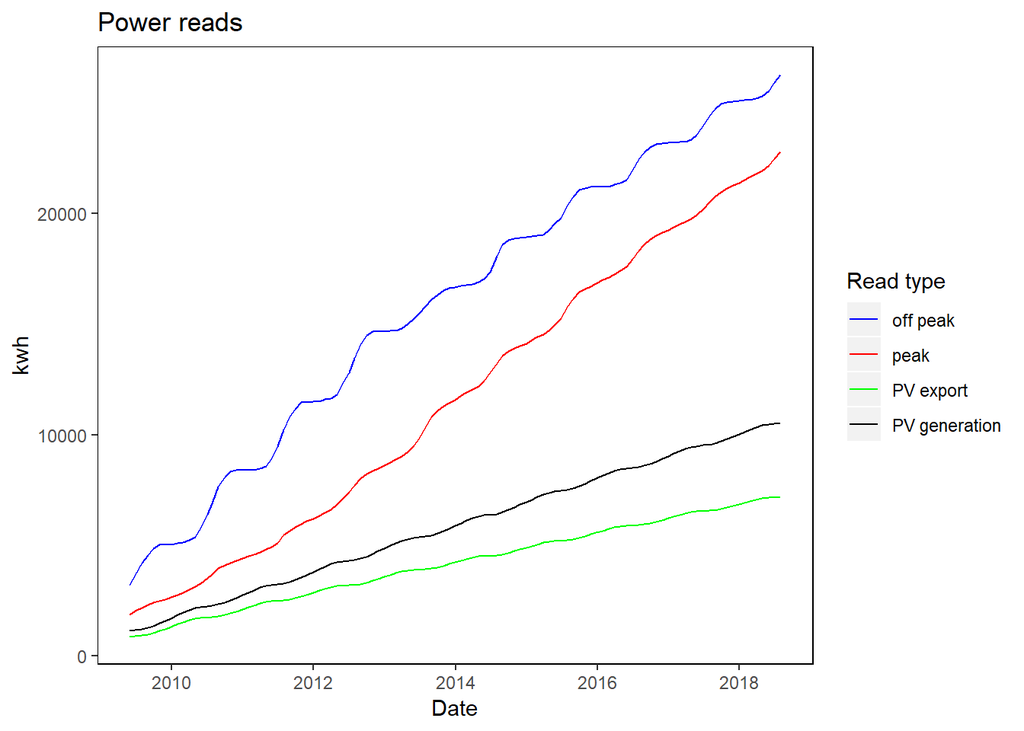

So far so good. You can see the meter reads going up over time with some bumps along the way, and if you look closely enough, some different slopes at different periods of time.

But from this plot it isn’t very easy to pull out the stories. What we actually need is usage - i.e. the increment between each read.

The first step to get usage is to get the diffence in each meter read from the previous reading. To do this, I used mutate() and lag(), which enabled me to add a new column with the lag function allowing me to subtract the same column from itself, but using one row prior.

So we now have the increment of power usage, generation and export between meter reads.

But guess what. Months have different numbers of days, and I couldn’t always do a meter read at the end of the month. So to compare between months, we need to get usage per day.

This was done by dividing each usage by the number of days in each increment. Happily because we’re using the date data type, calculating the number of days was a cinch.

Ok. Now we have something meaningful to work with. I did some more cleaning up by removing unnecessary intermediary columns and made a table called eUGE3 with months, years and seasons as factors. Unfotunately, because I’m a newbie, I couldn’t figure out a quick way to find the month which ends closest to each read date, so I just made some month, year and season lists and added them to the tibble using mutate.

So now, we’re pretty much done wiht the data manipulation. This is about to get exciting! Having recored all of this data over 9 years, we’re about to see what it looks like.

Let’s do some exploration first.

### Data exploration

Some time ago, before it became cool, and then became a money making exercise for the wealthy, we installed a small (1 kW) photovoltaic system connected to the grid. First up, we’re going to look at how the PV system is performing.

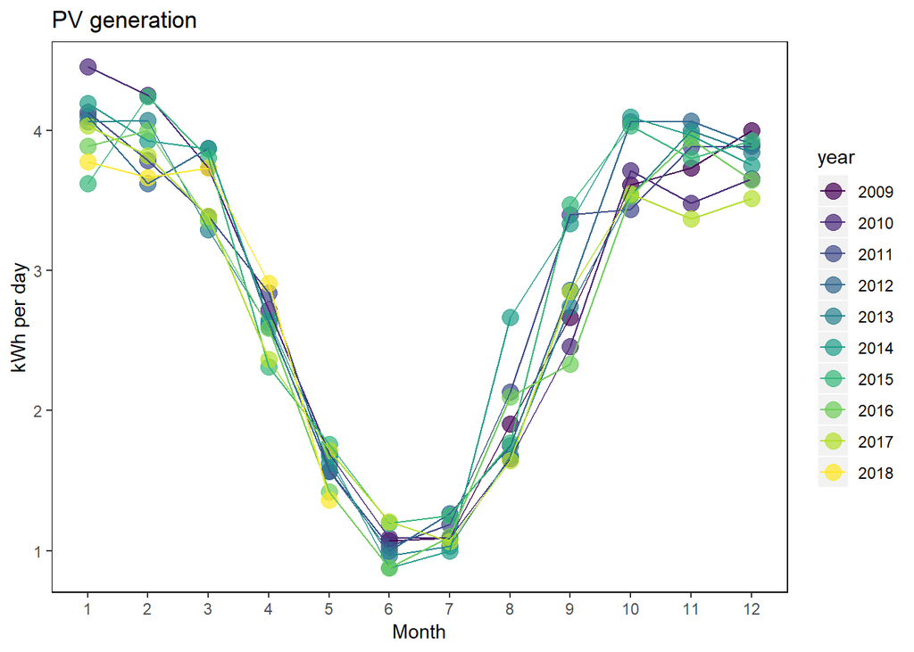

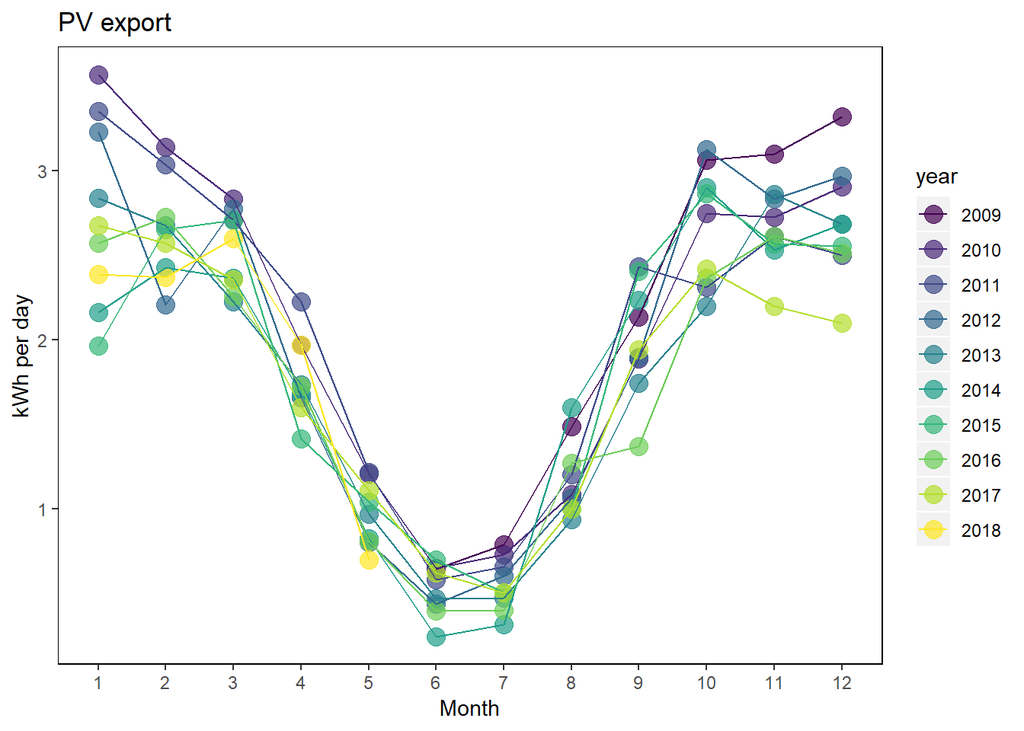

Note the seasonality. As to be expected, we’re generating and exporting much more elctricity in summer than in winter. Note that the spread in the export data over summer is greater than for the generation data. Again, this makes sense because over the years, the amount of the generated electricity that we consume within the household has varied.

We can look at performance by plotting PV generation and export against hours of operation.

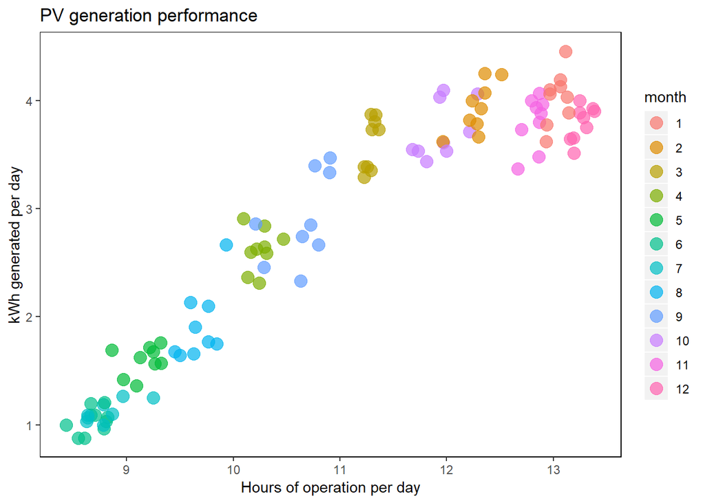

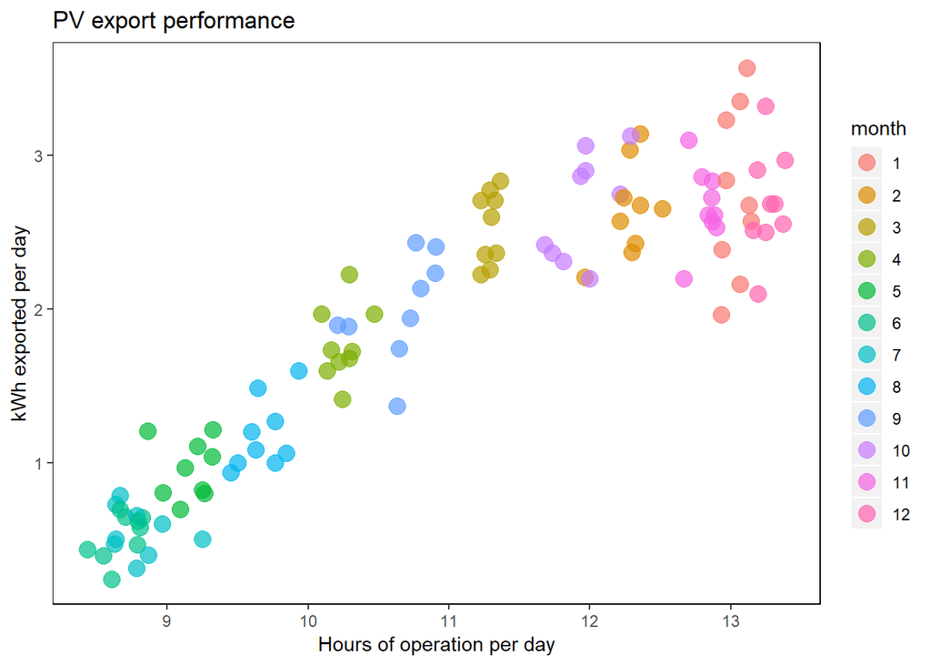

These aren’t just pretty graphs. They tell a story. You can see that as the hours of operation increase, the increase in generation tails off. In some years, export goes backwards as hours of operation increases. Interesting huh? I’ll let you think about why that may be so.

So, how are these panels performing over time?

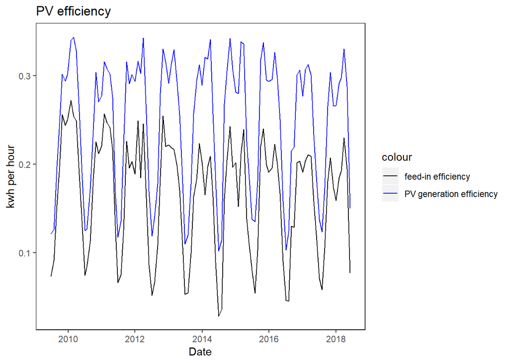

Here, PV efficiency is the amount of electricity that our teeny weeny 1 kW PV system generates per hour of operation. In summer we’re getting around 0.3 kW per hour. Winter looks depressing, doesn’t it?

Wondering what that dip in the middle of summer is? High temperatures do lead to lower panel performance. It would be interesting to get some temperature data and do some comparisons. Another explanation is that the panels face north and are tilted to get better mid-year performance. We also have large trees east and west. So during the long summer days when the sun rises in the south-east and sets and the south-west, there are many daylight hours when the inverter is working but there isn’t any direct light on the panels.

Don’t you love visualisation?

Now let’s take a look at consumption.

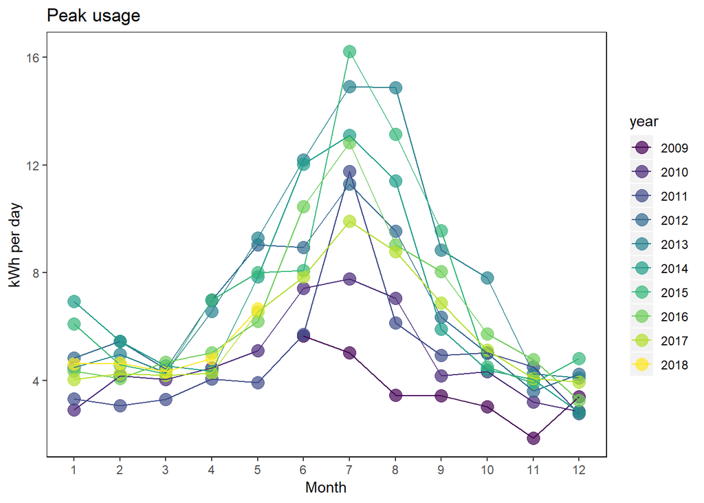

Again, note the seasonality of our usage of electricity, and the complete mismatch between PV generation and usage. Bummer huh!

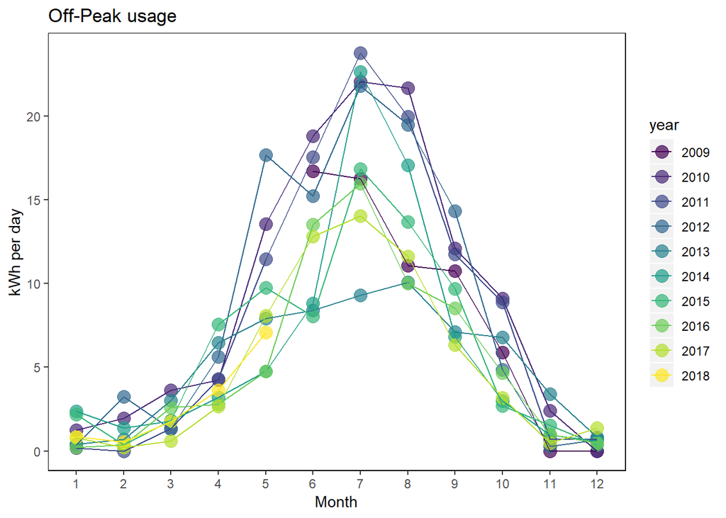

And for off-peak electricity, you can see our reliance on an off-peak heat pump in the early years, with less reliance in middle years due to the RC AC. More recently we have been playing with a mix of heat pump and heat bank in winter as our occupancy patterns change and we rely on that beautiful radiant heat from the heat bank to dry our towels and washing overnight.

So how do we compare to other households in our area?

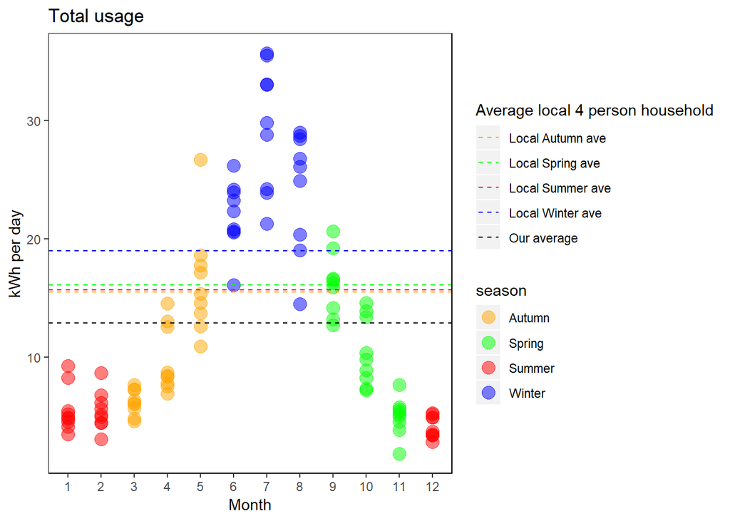

This is a plot of our total usage (peak + off-peak) over the 12 months of the year, for all of the 9 years. I’ve grouped by season to enable a comparison to an average 4 person household in our area, represented by the horizontal lines. The data are from http://energymadeeasy.gov.au. The black line represents the average for our household for the whole year. As you can see, we do pretty well, especially considering that we live in an old, leaky, weatherboard cottage and we are entirely reliant on electricity for our household energy, with excpetion of the occasional bbq, wok cooking and chimenea.

As you can see, there are many stories to be told.

Part of my task was to generate one final image. If I was limited to only 1 figure, I’d want to caputre all of the data. I got close. This is what it would look like.

Get ready for it… this is ‘eUGE’ !

## eUGE

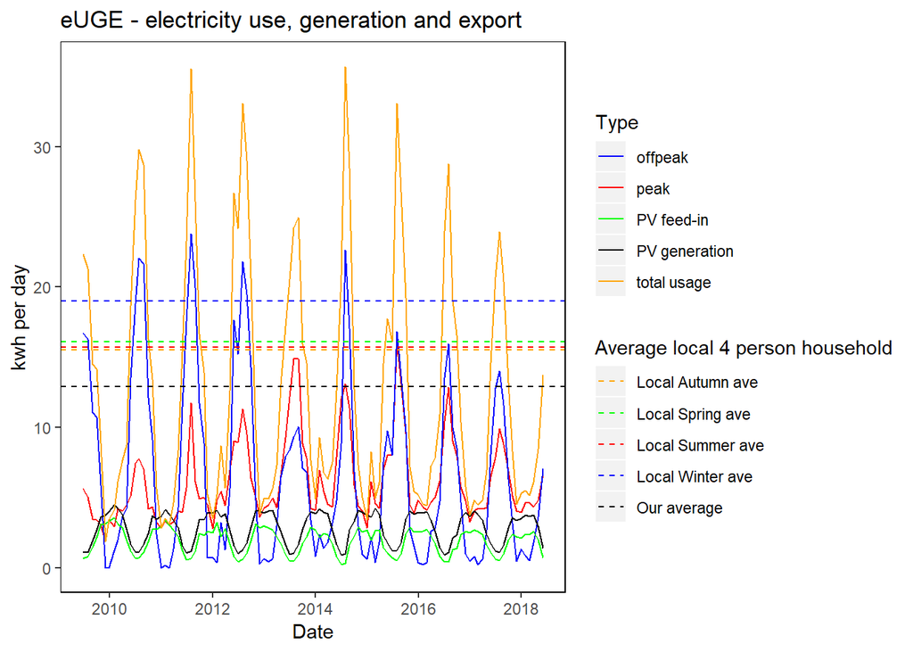

Nice huh? Because I’m so familiar with the data and all of the cirumstances , I can see all of the stories playing out in this figure. But good luck to anyone else.

### Key findings

#### Seasonality

Both energy use and generation in our household are highly seasonal.

Useage peaks in winter.

Generation peaks in summer.

Bummer, huh?

#### 4 person households - how we compare

Depsite living in a leaky 1949 weatherboard home run entirely on electricity, our total usage is less than the average local 4 person household. Can we do better? Hell yeah!!! Stay tuned. We’re currently designing an energy efficient home, due to be constructed in 2019. Proper orientation, double glazed uPVC windows, R6 insulation in the ceilings, R4 in the walls, internal thermal mass, properly sealed and blower door tested… you get the idea.

#### Take home messages

Unfortunately our electricity use and PV generation are completely out of sync. For now, that’s ok because we get a generous feed-in tarrif. Credits in summer help pay some of the winter bills. But we’re not expecting that to last long.

It looks like taking the current house off grid would nto only be a money sucking challenge, it would be counterproductive. We would need a big system to meet heating demand in winter, and then will have a massive surplus in summer without the ability to the displace dirty fossil fuels that our neighbours rely on.

Given that our main electricity use is heating, alternate fuels could be considered. Gas is avaiable but is a dirty fossil fuel (especially when you consider fugitive emissions), isn’t that cheap after all, and you loose more than half the heat up the flue. Wood could be used, but it costs, can be environmentally dubious, and requires work which we may not be up for in our twilight years.

### Next steps

More data exploration!

I am intimately familiar with this data, but even I found things I wasn’t expecting when trying different ways of visualising the data. There’s still more I’d like to try, and potentially a few more typos I need to iron out.

It was really important to realise that whilst the scary eUGE plot contains all of the stories, it’s pretty difficult for anyone but me to tease them out. So building up the story with some clear and simple plots is really important.

It would be interesting to transcribe some of the daily data, pull in some climate data from the BOM and test out some relationships.

We can do the same for water usage and rainfall, given that we have a tank plumbed in.

The modeller in me wants to go crazy with it. I’m resisting that urge, for now, anyway.

As we plan our new energy efficient house, we are considering heating options. Do we need to fork out big $ for a very efficient, effective and somewhat luxurious in-slab hydronic heating system? Do we suffice with a wood oven? Would salvaging our existing heat pump and heat bank be enough? Will we even need heating at all?

Whatever we end up with, rest assured that I will continue to record our meter readings and get back to you with some interesting comparisons, no doubt. Hopefully it won’t take me another 9 years!

Thanks for reading ;)